# String manipulation with stringr - Live session

Himanshi & Elena

noviembre 01, 2021 | 19:00:42 | CET

```r
library(devtools)
library(stringr)
library(knitr)
library(meme)
devtools::install_github("hadley/emo")
```

Welcome!😄 For this session we’re going to work with the **stringr** package (make sure you have installed it!) and **regex**. This package is designed to manipulate *strings*, recall that you can create them with either single quotes or double quotes.

Check stringr documentation: https://stringr.tidyverse.org/articles/from-base.html#order-strings-1

```r
string1 <- "This is a string"
string2 <- 'If you want to include a "quote" inside a string, please use single quotes'
```

## String manipulation basics

We will work with a simple list of dog breeds 🐶 ❤️

```r
dogs_data <- c("Border Collie","Akita","Labrador","Poodle","Miniature Schnauzer","Fox Terrier","Tibetan Mastiff")
```

1. Which is the **dog breed with the longest name** in the list? Please calculate it and sum the string length in the entire list.

```r
str_length(dogs_data)
```

```
## [1] 13  5  8  6 19 11 15
```

```r
sum(str_length(dogs_data)) #If you need to know the lenght of the entire list, you can just use sum()
```

```
## [1] 77
```

2. Are you sure that you got the right number? 🤔*Hint: beware of whitespaces*

```r
str_length(str_replace_all(dogs_data," ",""))
```

```
## [1] 12  5  8  6 18 10 14
```

3. Please indicate which breeds contain an **“a”** in its name.

```r
str_subset(dogs_data, "a")
```

```
## [1] "Akita"               "Labrador"            "Miniature Schnauzer"
## [4] "Tibetan Mastiff"
```

4. Did you realized that it only returns the breeds written in **lowercase**? Find a way to convert all breeds to lowercase and repeat the previous step.

```r
str_subset(str_to_lower(dogs_data), 'a')
```

```
## [1] "akita"               "labrador"            "miniature schnauzer"
## [4] "tibetan mastiff"
```

5. Look for the position of breeds with an **uppercase “I”** but make sure that it takes into account all breeds.

```r
str_subset(str_to_upper(dogs_data), 'I')
```

```
## [1] "BORDER COLLIE"       "AKITA"               "MINIATURE SCHNAUZER"
## [4] "FOX TERRIER"         "TIBETAN MASTIFF"
```

6. Count the number of **“t” letters** in the list.

```r
str_count(dogs_data, "t")
```

```
## [1] 0 1 0 0 1 0 2
```

7. Replace with an exclamation the **first “a”** in each breed. *Hint: beware of lower and uppercases.*

```r
str_replace(str_to_lower(dogs_data), "a", "!")
```

```
## [1] "border collie"       "!kita"               "l!brador"
## [4] "poodle"              "mini!ture schnauzer" "fox terrier"
## [7] "tibet!n mastiff"
```

```r
str_sub(str_subset(dogs_data, "schnauzer"), 11, 19)
```

```
## character(0)
```

## Manipulating sentences

9. You can also work with sentences and convert string to **sentence**. Use this sentence *" schnauzers were Originally Bred to be ratters, guard Dogs, and All-purpose Dogs On German farms."*

```r
str_to_sentence("  schnauzers were Originally Bred to be ratters, guard Dogs,     and All-purpose Dogs On German farms.")
```

```
## [1] "  Schnauzers were originally bred to be ratters, guard dogs,     and all-purpose dogs on german farms."
```

10. The sentence looks better, but we still have some **white spaces** in between it. Please trim it.

```r
str_trim("  Schnauzers were originally bred to be ratters, guard dogs,     and all-purpose dogs on german farms.")
```

```
## [1] "Schnauzers were originally bred to be ratters, guard dogs,     and all-purpose dogs on german farms."
```

11. Some **white spaces** in between are still there, please remove them as well.

```r
str_squish("  Schnauzers were originally bred to be ratters, guard dogs,     and all-purpose dogs on german farms.")
```

```
## [1] "Schnauzers were originally bred to be ratters, guard dogs, and all-purpose dogs on german farms."
```

12. Now we actually want that **white space back**, but we only need it at the beginning and end of it.

```r
str_pad("Schnauzers don't bite", width = 60, side="both")
```

```
## [1] "                   Schnauzers don't bite                    "
```

## Using RegEx

Check this useful **cheat sheet**: https://evoldyn.gitlab.io/evomics-2018/ref-sheets/R_strings.pdf

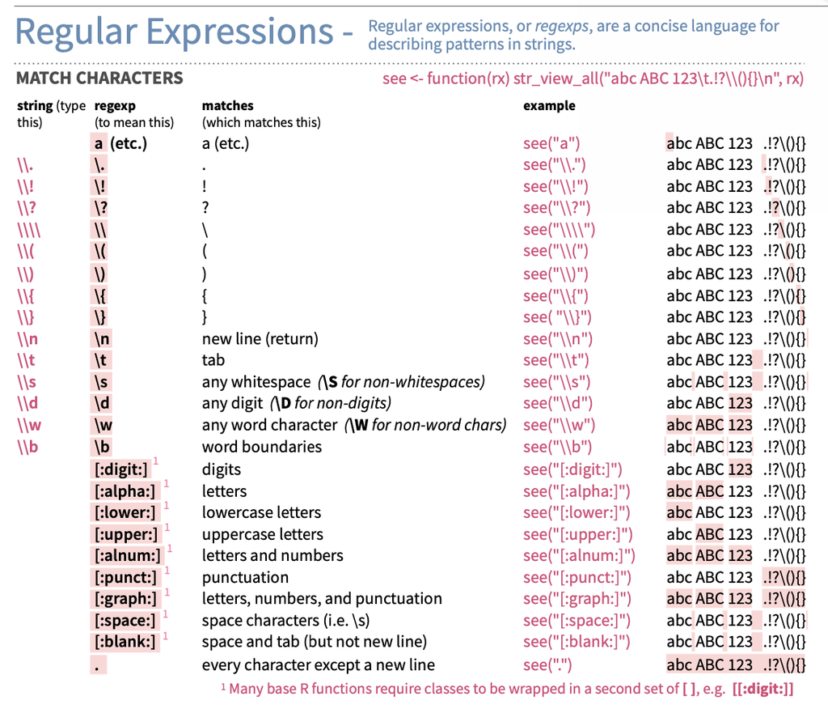

```r
knitr::include_graphics("/Users/elena/Documents/Hertie MPP/2nd Year/Data Science/regexpic.png")
```

### The next list contains words with some **pronunciations and typos**. Our task is to standarize all the names and remove useless puntuations.

```r
dogs_data <- c("Border Collie", "akita!", "LABRADOR", "Poodle.", "miniature schnauzer", "FOX TERRIER",
"Tibetan Mastiff")
```

13. Remove **punctuations** to standarize the list and save it as a new object called *“clean_list”*.

```r
clean_list <- str_replace_all(dogs_data, "[:punct:]","")
```

14. We want to rewrite all breeds in a **nice format**, use the previously saved object (clean_list), in which only the first letter is **uppercased**.

```r
str_to_title(clean_list)
```

```
## [1] "Border Collie"       "Akita"               "Labrador"
## [4] "Poodle"              "Miniature Schnauzer" "Fox Terrier"
## [7] "Tibetan Mastiff"
```

### Now we will work a list containing the number of dogs by breed and the last year they were counted.

```r
dog_count <- c("Border Collie 23 2019", "Akita 11 2020", "Labrador 24 2021", "Poodle 1 2017", "Miniature Schnauzer 80 2018", "Fox Terrier 5 2009", "Tibetan Mastiff 6 2010")
```

15. In which position is the **first number** in the strings? Please locate it.

```r
str_locate(dog_count, '\\d') # '\\d' detects digits in strings
```

```
##      start end
## [1,]    15  15
## [2,]     7   7
## [3,]    10  10
## [4,]     8   8
## [5,]    21  21
## [6,]    13  13
## [7,]    17  17
```

16. In which position are **all the numbers** in the strings? Please locate it.

```r
str_locate_all(dog_count, '\\d') # '\\d' detects digits in strings
```

```
## [[1]]
##      start end
## [1,]    15  15
## [2,]    16  16
## [3,]    18  18
## [4,]    19  19
## [5,]    20  20
## [6,]    21  21
##
## [[2]]
##      start end
## [1,]     7   7
## [2,]     8   8
## [3,]    10  10
## [4,]    11  11
## [5,]    12  12
## [6,]    13  13
##
## [[3]]
##      start end
## [1,]    10  10
## [2,]    11  11
## [3,]    13  13
## [4,]    14  14
## [5,]    15  15
## [6,]    16  16
##
## [[4]]
##      start end
## [1,]     8   8
## [2,]    10  10
## [3,]    11  11
## [4,]    12  12
## [5,]    13  13
##
## [[5]]
##      start end
## [1,]    21  21
## [2,]    22  22
## [3,]    24  24
## [4,]    25  25
## [5,]    26  26
## [6,]    27  27
##
## [[6]]
##      start end
## [1,]    13  13
## [2,]    15  15
## [3,]    16  16
## [4,]    17  17
## [5,]    18  18
##
## [[7]]
##      start end
## [1,]    17  17
## [2,]    19  19
## [3,]    20  20
## [4,]    21  21
## [5,]    22  22
```

17. Let’s use regex to extract the **quantity of dogs by breed**. We first need to locate numbers in the list

```r
str_extract(dog_count, '\\d+') # '\\d+' detects 1 or more digits in strings
```

```
## [1] "23" "11" "24" "1"  "80" "5"  "6"
```

18. Let’s use regex to extract the **quantity and year** of the last counting of dogs by breed. We first need to locate numbers in the list

```r
str_extract_all(dog_count, '\\d+') # '\\d+' detects 1 or more digits in strings
```

```
## [[1]]
## [1] "23"   "2019"
##
## [[2]]
## [1] "11"   "2020"
##
## [[3]]
## [1] "24"   "2021"
##
## [[4]]
## [1] "1"    "2017"
##
## [[5]]
## [1] "80"   "2018"
##
## [[6]]
## [1] "5"    "2009"
##
## [[7]]
## [1] "6"    "2010"
```

```r
dog_count_pattern <- c("Border Collie_23", "Akita_11", "Labrador_24", "Poodle_1", "Miniature Schnauzer_80", "Fox Terrier_3", "Tibetan Mastiff_6")
```

19. Split the **name** and the **quantity** of dogs using str_split().

```r
str_split(dog_count_pattern, "_")
```

```
## [[1]]
## [1] "Border Collie" "23"
##
## [[2]]
## [1] "Akita" "11"
##
## [[3]]
## [1] "Labrador" "24"
##
## [[4]]
## [1] "Poodle" "1"
##
## [[5]]
## [1] "Miniature Schnauzer" "80"
##
## [[6]]
## [1] "Fox Terrier" "3"
##
## [[7]]
## [1] "Tibetan Mastiff" "6"
```

20. Sometimes it is useful the check the data in a character **matrix format**. Please provide a matrix showing breeds and count of dogs. *Hint: take into account that we only have 2 elements.*

```r
str_split_fixed(dog_count_pattern, "_", 2)
```

```
##      [,1]                  [,2]
## [1,] "Border Collie"       "23"
## [2,] "Akita"               "11"
## [3,] "Labrador"            "24"
## [4,] "Poodle"              "1"
## [5,] "Miniature Schnauzer" "80"
## [6,] "Fox Terrier"         "3"
## [7,] "Tibetan Mastiff"     "6"
```

21. Detect breeds whose name is composed of **2 words** and return a logical vector (TRUE, FALSE).

```r
str_detect(dog_count_pattern, " ")
```

```
## [1]  TRUE FALSE FALSE FALSE  TRUE  TRUE  TRUE
```

```r
str_detect(dog_count_pattern, "[:space:]") #using regex
```

```
## [1]  TRUE FALSE FALSE FALSE  TRUE  TRUE  TRUE
```

[figure not shown]

```r
doggos_pic <- ("https://i.imgflip.com/4/4t0m5.jpg")

meme(doggos_pic, upper = (" \n very [:punct:]"), lower = ("             \n      so many strings                                         \n wow data science "), size = 1, color = "green", font = "Helvetica", vjust = 0.7, r = 0.15, density = NULL)
```